# R Notebook

Modified DataCamp Project *Wrangling and Visualizing Musical Data* by Kris Shaffer

## 1. Introduction

How do musicians choose the chords they use in their songs? Do guitarists, pianists, and singers gravitate towards different kinds of harmony?

We can uncover trends in the kinds of chord progressions used by popular artists by analyzing the harmonic data provided in the [McGill Billboard Dataset](http://ddmal.music.mcgill.ca/research/billboard). This dataset includes professionally tagged chords for several hundred pop/rock songs representative of singles that made the Billboard Hot 100 list between 1958 and 1991. Using the data-wrangling tools available in the `dplyr` package, and the visualization tools available in the `ggplot2` package, we can explore the most common chords and chord progressions in these songs, and contrast the harmonies of some guitar-led and piano-led artists to see where the “affordances” of those instruments may affect the chord choices artists make.

Required CRAN packages for this coding project are: `pacman, tidyverse, DT, kableExtra, scales`

### Sample of Billboard chords data table

| year | chord | root_integer | root_roman | quality | title_compressed | artist_compressed | title | artist |
| --- | --- | --- | --- | --- | --- | --- | --- | --- |
| 1961 | A:min | 9 | VI | min | idon’tmind | jamesbrown | I Don’t Mind | James Brown |
| 1961 | C:maj | 0 | I | maj | idon’tmind | jamesbrown | I Don’t Mind | James Brown |
| 1961 | A:min | 9 | VI | min | idon’tmind | jamesbrown | I Don’t Mind | James Brown |
| 1961 | C:maj | 0 | I | maj | idon’tmind | jamesbrown | I Don’t Mind | James Brown |
| 1961 | A:min | 9 | VI | min | idon’tmind | jamesbrown | I Don’t Mind | James Brown |
| 1961 | C:maj | 0 | I | maj | idon’tmind | jamesbrown | I Don’t Mind | James Brown |
| 1961 | A:min | 9 | VI | min | idon’tmind | jamesbrown | I Don’t Mind | James Brown |

### List of Artists

|  | Artist | Song | Year |
| --- | --- | --- | --- |
| 1 | A Taste Of Honey | Sukiyaki | 1981 |
| 2 | Abba | Chiquitita | 1979 |
| 3 | Abba | Fernando | 1976 |
| 4 | Abba | Knowing Me, Knowing You | 1977 |
| 5 | Abba | On And On And On | 1981 |
| 6 | Abba | Take A Chance On Me | 1978 |
| 7 | Aerosmith | Last Child | 1976 |
| 8 | Al Green | Oh Me, Oh My (Dreams In My Arms) | 1975 |
| 9 | Alabama | Take Me Down | 1982 |
| 10 | Alan O'Day | Undercover Angel | 1977 |

[output cut: 635 more lines]

## 2. The most common chords

As seen in the previous task, this is a *tidy* dataset: each row represents a single observation, and each column a particular variable or attribute of that observation. Note that the metadata for each song (title, artist, year) is repeated for each chord – like “I Don’t Mind” by James Brown, 1961 – while the unique attributes of each chord (chord symbol, chord quality, and analytical designations like integer and Roman-numeral notation) is included once for each chord change.

A key element of the style of any popular musical artist is the kind of chords they use in their songs. But not all chords are created equal! In addition to differences in how they sound, some chords are simply easier to play than others. On top of that, some chords are easier to play on one instrument than they are on another. And while master musicians can play a wide variety of chords and progressions with ease, it’s not a stretch to think that even the best musicians may choose more “idiomatic” chords and progressions for their instrument.

To start to explore that, let’s look at the most common chords in the McGill Billboard Dataset.

### Amount and share of recorded chords

|  | Chord | Amount | in % |
| --- | --- | --- | --- |
| 1 | C:maj | 1183 | 6.16 |
| 2 | G:maj | 1140 | 5.94 |
| 3 | A:maj | 1071 | 5.58 |
| 4 | D:maj | 1054 | 5.49 |
| 5 | F:maj | 859 | 4.47 |
| 6 | E:maj | 839 | 4.37 |
| 7 | Bb:maj | 718 | 3.74 |
| 8 | B:maj | 503 | 2.62 |
| 9 | Ab:maj | 375 | 1.95 |
| 10 | Eb:maj | 360 | 1.88 |

[output cut: 668 more lines]

## 3. Visualizing the most common chords

Of course, it’s easier to get a feel for just how common some of these chords are if we graph them and show the percentage of the total chord count represented by each chord. Musicians may notice right away that the most common chords in this corpus are chords that are easy to play on both the guitar and the piano: C, G, A, and D major and to an extent, F and E major. (They also belong to keys, or scales, that are easy to play on most instruments, so they fit well with melodies and solos, as well.) After that, there is a steep drop off in the frequency with which individual chords appear.

To illustrate the most common chords, I decided to plot the percentage of the total chords in the McGill Billboard dataset in a first level of the circle of fifths because the top 10 chords of the McGill Billboard data represent the first ten chords of the circle.

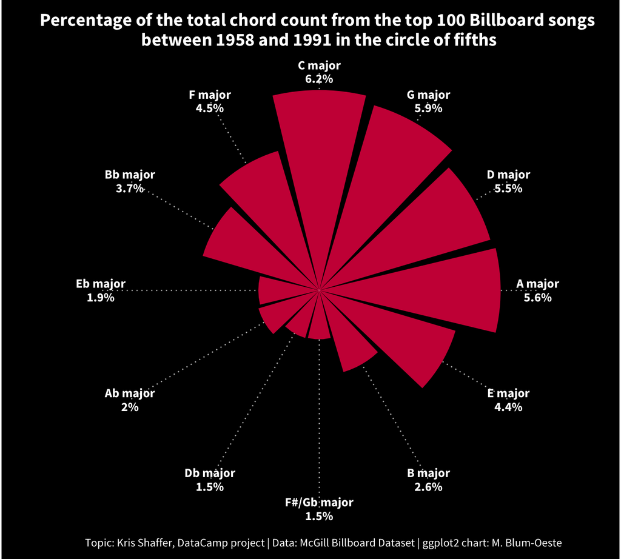

## 4. Chord “bigrams”

Just as some chords are more common and more idiomatic than others, not all chord *progressions* are created equal. To look for common patterns in the structuring of chord progressions, we can use many of the same modes of analysis used in text-mining to analyze phrases. A chord change is simply a *bigram* - a two-“word” phrase - composed of a starting chord and a following chord. Here are the top 12 of the most common two-chord “phrases” in the McGill Billboard dataset.

### Top 12 of the most common bigrams

| Chord Progressions | Amount in the Billboard dataset |
| --- | --- |
| G:maj D:maj | 241 |
| C:maj F:maj | 234 |
| C:maj G:maj | 217 |
| B:maj E:maj | 202 |
| F:maj C:maj | 195 |
| A:maj E:maj | 190 |
| A:maj D:maj | 189 |
| D:maj G:maj | 185 |
| G:maj C:maj | 185 |
| D:maj A:maj | 179 |
| E:maj A:maj | 175 |
| F:maj Bb:maj | 143 |

## 5. Visualizing the most common chord progressions

We can get a better sense of just how popular some of these chord progressions are if we plot them as a percentage of the top 12 most common chord progressions on a bar chart. The chart mimics a keyboard.

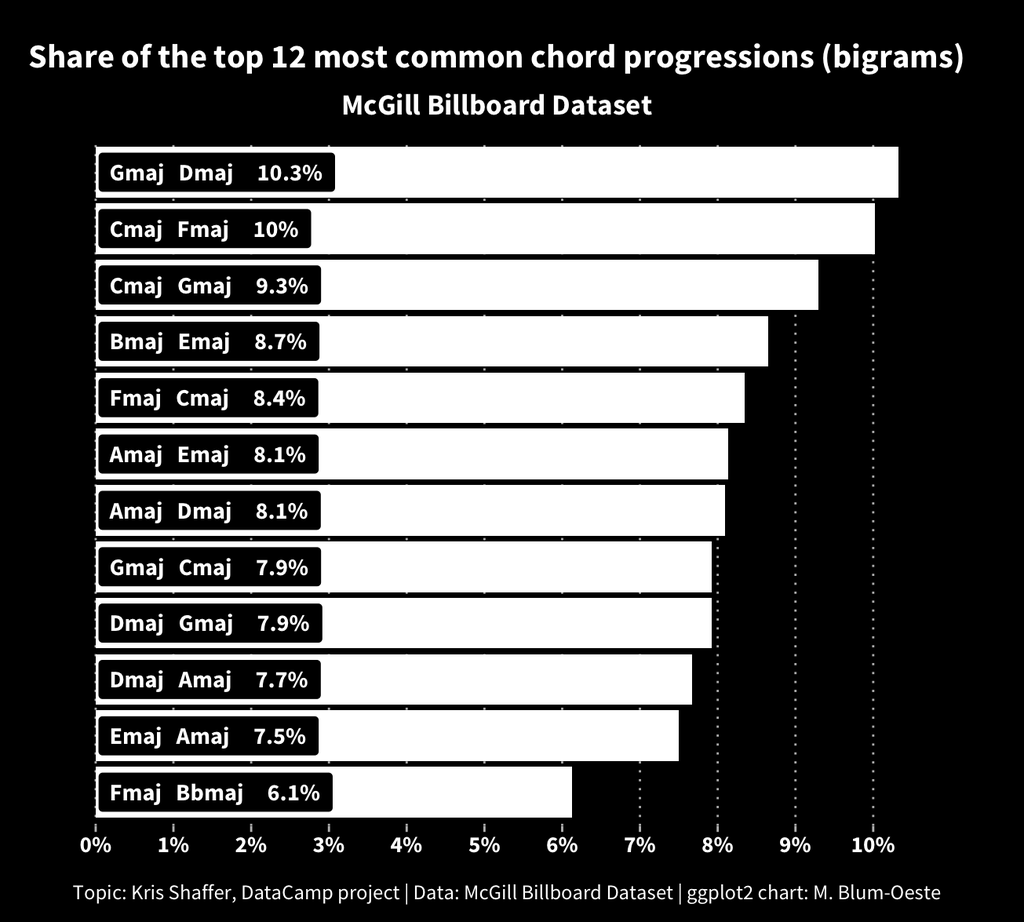

## 6. Finding the most common artists

As noted above, the most common chords (and chord bigrams) are those that are easy to play on both the guitar and the piano. If the degree to which these chords are idiomatic on guitar or piano (or both) *determine* how common they are, we would expect to find the more idiomatic guitar chords (C, G, D, A, and E major) to be more common in guitar-driven songs, but we would expect the more idiomatic piano chords (C, F, G, D, and B-flat major) to be more common in piano-driven songs. (Note that there is some overlap between these two instruments.)

The McGill Billboard dataset does not come with songs tagged as “piano-driven” or “guitar-driven,” so to test this hypothesis, we’ll have to do that manually. Rather than make this determination for every song in the corpus, let’s focus on just a few to see if the hypothesis has some validity. If so, then we can think about tagging more artists in the corpus and testing the hypothesis more exhaustively.

### Artists with the most songs in the dataset

| Artist | Number of Songs |
| --- | --- |
| Elvis Presley | 13 |
| Brenda Lee | 9 |
| Dion | 8 |
| Bob Seger | 7 |
| James Brown | 7 |
| Kenny Rogers | 7 |
| The Beatles | 7 |
| Chicago | 6 |
| Dr. Hook | 6 |
| Eric Clapton | 6 |
| John Denver | 6 |
| Johnny Tillotson | 6 |
| The Beach Boys | 6 |
| Abba | 5 |
| Billy Idol | 5 |
| Cliff Richard | 5 |
| Glen Campbell | 5 |
| The Rolling Stones | 5 |
| Billy Joel | 4 |
| Cheap Trick | 4 |
| Cyndi Lauper | 4 |
| David Bowie | 4 |
| Elton John | 4 |
| Genesis | 4 |
| Heart | 4 |
| Jackson Browne | 4 |
| Little River Band | 4 |
| Michael Jackson | 4 |
| Pat Benatar | 4 |
| Stevie Wonder | 4 |
| The 5th Dimension | 4 |
| The Everly Brothers | 4 |
| The Miracles | 4 |
| Wilson Pickett | 4 |

## 7. Tagging the corpus

There are relatively few artists in this list whose music is demonstrably “piano-driven,” but we can identify a few that generally emphasize keyboards over guitar: Abba, Billy Joel, Elton John, Stevie Wonder and Pet Shop Boys totaling

| no_songs |
| --- |
| 20 |

[output not shown]

songs).

### Selected guitar- and piano-driven artists

| Artist | Instrument | Number of Songs |
| --- | --- | --- |
| Eric Clapton | guitar | 6 |
| Jackson Browne | guitar | 4 |
| Led Zeppelin | guitar | 2 |
| Pink Floyd | guitar | 2 |
| The Rolling Stones | guitar | 5 |
| Abba | piano | 5 |
| Billy Joel | piano | 4 |
| Elton John | piano | 4 |
| Pet Shop Boys | piano | 3 |
| Stevie Wonder | piano | 4 |

## 8. Comparing chords in piano-driven and guitar-driven songs

Let’s take a look at any difference in how common chords are in these two song groups. To clean things up, we’ll just focus on the 13 chords most common in the McGill Billboard dataset and included in the circle of fifths.

So with all the appropriate caveats, it seems like the instrument-based-harmony hypothesis does have some merit and is worth further examination.

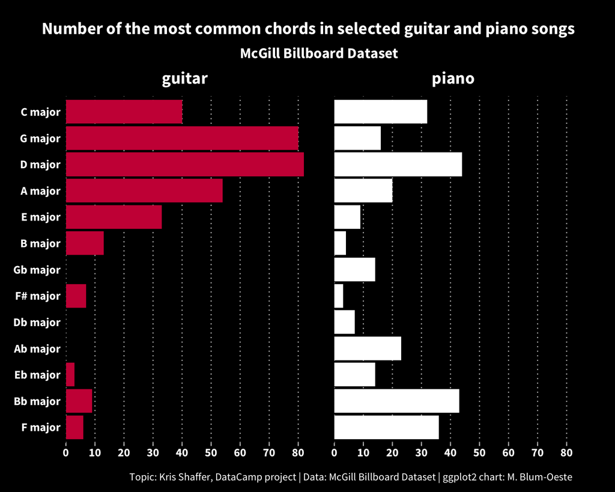

## 9. Comparing chord bigrams in piano-driven and guitar-driven songs

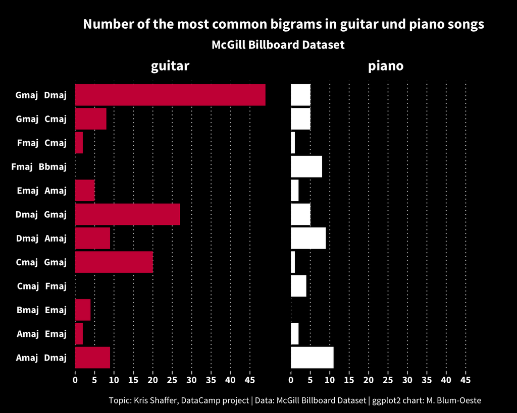

## 10. Conclusion

We set out asking if the degree to which a chord is “idiomatic” on an instrument affects how frequently it is used by a songwriter. It seems that is indeed the case. In a large representative sample of pop/rock songs from the historical Billboard charts, the chords most often learned first by guitarists and pianists are the most common. In fact, chords commonly deemed *easy* or *beginner-friendly* on **both** piano and guitar are far and away the most common in the corpus.

There are still more questions to explore with this dataset. What about band-driven genres like classic R&B and funk, where artists like James Brown and Chicago build chords from a large number of instruments each playing a single note? What about “progressive” bands like Yes and Genesis, where “easy” and “idiomatic” may be less of a concern during the songwriting process? And what if we compared this dataset to a collection of chords from classical songs, jazz charts, folk songs, liturgical songs?

There’s only one way to find out!